# Credit Card Fraud Detection

This dataset is available at [Kaggle](https://www.kaggle.com/mlg-ulb/creditcardfraud). It contains transactions made by credit cards in September 2013 by European cardholders.

## Initial Observations

This dataset is heavily unbalanced, with only a small minority of the transactions being fraudulent. It also only contains numeric values as a result of a PCA transformation. First, load in the required libraries and take a look at the data.

```python
import pandas as pd
import numpy as np
import tensorflow as tf
from tensorflow import keras
import matplotlib.pyplot as plt
import seaborn as sns
from sklearn.model_selection import train_test_split
from sklearn.preprocessing import RobustScaler
from sklearn.metrics import confusion_matrix
import sklearn
import warnings
warnings.filterwarnings("ignore")
%matplotlib inline
```

```python
df = pd.read_csv("creditcard.csv")
df.head()
```

|  | Time | V1 | V2 | V3 | V4 | V5 | V6 | V7 | V8 | V9 | ... | V21 | V22 | V23 | V24 | V25 | V26 | V27 | V28 | Amount | Class |
| --- | --- | --- | --- | --- | --- | --- | --- | --- | --- | --- | --- | --- | --- | --- | --- | --- | --- | --- | --- | --- | --- |
| 0 | 0.0 | -1.359807 | -0.072781 | 2.536347 | 1.378155 | -0.338321 | 0.462388 | 0.239599 | 0.098698 | 0.363787 | ... | -0.018307 | 0.277838 | -0.110474 | 0.066928 | 0.128539 | -0.189115 | 0.133558 | -0.021053 | 149.62 | 0 |
| 1 | 0.0 | 1.191857 | 0.266151 | 0.166480 | 0.448154 | 0.060018 | -0.082361 | -0.078803 | 0.085102 | -0.255425 | ... | -0.225775 | -0.638672 | 0.101288 | -0.339846 | 0.167170 | 0.125895 | -0.008983 | 0.014724 | 2.69 | 0 |
| 2 | 1.0 | -1.358354 | -1.340163 | 1.773209 | 0.379780 | -0.503198 | 1.800499 | 0.791461 | 0.247676 | -1.514654 | ... | 0.247998 | 0.771679 | 0.909412 | -0.689281 | -0.327642 | -0.139097 | -0.055353 | -0.059752 | 378.66 | 0 |
| 3 | 1.0 | -0.966272 | -0.185226 | 1.792993 | -0.863291 | -0.010309 | 1.247203 | 0.237609 | 0.377436 | -1.387024 | ... | -0.108300 | 0.005274 | -0.190321 | -1.175575 | 0.647376 | -0.221929 | 0.062723 | 0.061458 | 123.50 | 0 |
| 4 | 2.0 | -1.158233 | 0.877737 | 1.548718 | 0.403034 | -0.407193 | 0.095921 | 0.592941 | -0.270533 | 0.817739 | ... | -0.009431 | 0.798278 | -0.137458 | 0.141267 | -0.206010 | 0.502292 | 0.219422 | 0.215153 | 69.99 | 0 |

5 rows × 31 columns

```python
df.describe()
```

|  | Time | V1 | V2 | V3 | V4 | V5 | V6 | V7 | V8 | V9 | ... | V21 | V22 | V23 | V24 | V25 | V26 | V27 | V28 | Amount | Class |
| --- | --- | --- | --- | --- | --- | --- | --- | --- | --- | --- | --- | --- | --- | --- | --- | --- | --- | --- | --- | --- | --- |
| count | 284807.000000 | 2.848070e+05 | 2.848070e+05 | 2.848070e+05 | 2.848070e+05 | 2.848070e+05 | 2.848070e+05 | 2.848070e+05 | 2.848070e+05 | 2.848070e+05 | ... | 2.848070e+05 | 2.848070e+05 | 2.848070e+05 | 2.848070e+05 | 2.848070e+05 | 2.848070e+05 | 2.848070e+05 | 2.848070e+05 | 284807.000000 | 284807.000000 |
| mean | 94813.859575 | 1.165980e-15 | 3.416908e-16 | -1.373150e-15 | 2.086869e-15 | 9.604066e-16 | 1.490107e-15 | -5.556467e-16 | 1.177556e-16 | -2.406455e-15 | ... | 1.656562e-16 | -3.444850e-16 | 2.578648e-16 | 4.471968e-15 | 5.340915e-16 | 1.687098e-15 | -3.666453e-16 | -1.220404e-16 | 88.349619 | 0.001727 |
| std | 47488.145955 | 1.958696e+00 | 1.651309e+00 | 1.516255e+00 | 1.415869e+00 | 1.380247e+00 | 1.332271e+00 | 1.237094e+00 | 1.194353e+00 | 1.098632e+00 | ... | 7.345240e-01 | 7.257016e-01 | 6.244603e-01 | 6.056471e-01 | 5.212781e-01 | 4.822270e-01 | 4.036325e-01 | 3.300833e-01 | 250.120109 | 0.041527 |
| min | 0.000000 | -5.640751e+01 | -7.271573e+01 | -4.832559e+01 | -5.683171e+00 | -1.137433e+02 | -2.616051e+01 | -4.355724e+01 | -7.321672e+01 | -1.343407e+01 | ... | -3.483038e+01 | -1.093314e+01 | -4.480774e+01 | -2.836627e+00 | -1.029540e+01 | -2.604551e+00 | -2.256568e+01 | -1.543008e+01 | 0.000000 | 0.000000 |
| 25% | 54201.500000 | -9.203734e-01 | -5.985499e-01 | -8.903648e-01 | -8.486401e-01 | -6.915971e-01 | -7.682956e-01 | -5.540759e-01 | -2.086297e-01 | -6.430976e-01 | ... | -2.283949e-01 | -5.423504e-01 | -1.618463e-01 | -3.545861e-01 | -3.171451e-01 | -3.269839e-01 | -7.083953e-02 | -5.295979e-02 | 5.600000 | 0.000000 |
| 50% | 84692.000000 | 1.810880e-02 | 6.548556e-02 | 1.798463e-01 | -1.984653e-02 | -5.433583e-02 | -2.741871e-01 | 4.010308e-02 | 2.235804e-02 | -5.142873e-02 | ... | -2.945017e-02 | 6.781943e-03 | -1.119293e-02 | 4.097606e-02 | 1.659350e-02 | -5.213911e-02 | 1.342146e-03 | 1.124383e-02 | 22.000000 | 0.000000 |
| 75% | 139320.500000 | 1.315642e+00 | 8.037239e-01 | 1.027196e+00 | 7.433413e-01 | 6.119264e-01 | 3.985649e-01 | 5.704361e-01 | 3.273459e-01 | 5.971390e-01 | ... | 1.863772e-01 | 5.285536e-01 | 1.476421e-01 | 4.395266e-01 | 3.507156e-01 | 2.409522e-01 | 9.104512e-02 | 7.827995e-02 | 77.165000 | 0.000000 |
| max | 172792.000000 | 2.454930e+00 | 2.205773e+01 | 9.382558e+00 | 1.687534e+01 | 3.480167e+01 | 7.330163e+01 | 1.205895e+02 | 2.000721e+01 | 1.559499e+01 | ... | 2.720284e+01 | 1.050309e+01 | 2.252841e+01 | 4.584549e+00 | 7.519589e+00 | 3.517346e+00 | 3.161220e+01 | 3.384781e+01 | 25691.160000 | 1.000000 |

8 rows × 31 columns

```python
print(round(df['Class'].value_counts()[1]/len(df) * 100, 3), "% are fraudulent")
```

```
0.173 % are fraudulent
```

As we can see only a small minority of the dataset contains fraudulent transactions. Therefore, a model could get a high accuracy if it just guessed not fraudulent for all transactions and would not be effective at preventing fraudulent transactions.

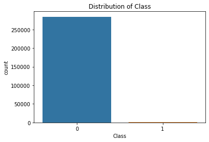

```python
sns.countplot('Class', data=df)
plt.title("Distribution of Class")
```

```
(0.0, 25691.16)
```

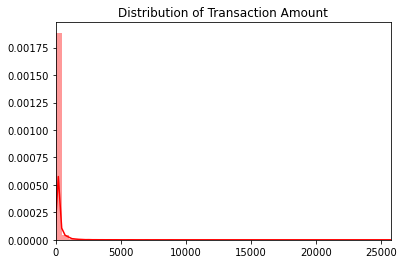

```python
sns.distplot(df['Amount'].values, color="red")
plt.title("Distribution of Transaction Amount")
plt.xlim([min(df['Amount'].values), max(df['Amount'].values)])
```

## Data preparation

The Time and Amount columns should also be scaled to match all the other columns.

```python
robust = RobustScaler()

df['scaled_amount'] = robust.fit_transform(df['Amount'].values.reshape(-1, 1))
df['scaled_time'] = robust.fit_transform(df['Time'].values.reshape(-1, 1))

df.drop(['Time', 'Amount'], axis=1, inplace=True)

scaled_amount = df['scaled_amount']
scaled_time = df['scaled_time']

# Insert the scaled columns at the front of the dataframe

df.drop(['scaled_amount', 'scaled_time'], axis=1, inplace=True)
df.insert(0, 'scaled_amount', scaled_amount)
df.insert(1, 'scaled_time', scaled_time)


df.head()
```

|  | scaled_amount | scaled_time | V1 | V2 | V3 | V4 | V5 | V6 | V7 | V8 | ... | V20 | V21 | V22 | V23 | V24 | V25 | V26 | V27 | V28 | Class |
| --- | --- | --- | --- | --- | --- | --- | --- | --- | --- | --- | --- | --- | --- | --- | --- | --- | --- | --- | --- | --- | --- |
| 0 | 1.783274 | -0.994983 | -1.359807 | -0.072781 | 2.536347 | 1.378155 | -0.338321 | 0.462388 | 0.239599 | 0.098698 | ... | 0.251412 | -0.018307 | 0.277838 | -0.110474 | 0.066928 | 0.128539 | -0.189115 | 0.133558 | -0.021053 | 0 |
| 1 | -0.269825 | -0.994983 | 1.191857 | 0.266151 | 0.166480 | 0.448154 | 0.060018 | -0.082361 | -0.078803 | 0.085102 | ... | -0.069083 | -0.225775 | -0.638672 | 0.101288 | -0.339846 | 0.167170 | 0.125895 | -0.008983 | 0.014724 | 0 |
| 2 | 4.983721 | -0.994972 | -1.358354 | -1.340163 | 1.773209 | 0.379780 | -0.503198 | 1.800499 | 0.791461 | 0.247676 | ... | 0.524980 | 0.247998 | 0.771679 | 0.909412 | -0.689281 | -0.327642 | -0.139097 | -0.055353 | -0.059752 | 0 |
| 3 | 1.418291 | -0.994972 | -0.966272 | -0.185226 | 1.792993 | -0.863291 | -0.010309 | 1.247203 | 0.237609 | 0.377436 | ... | -0.208038 | -0.108300 | 0.005274 | -0.190321 | -1.175575 | 0.647376 | -0.221929 | 0.062723 | 0.061458 | 0 |
| 4 | 0.670579 | -0.994960 | -1.158233 | 0.877737 | 1.548718 | 0.403034 | -0.407193 | 0.095921 | 0.592941 | -0.270533 | ... | 0.408542 | -0.009431 | 0.798278 | -0.137458 | 0.141267 | -0.206010 | 0.502292 | 0.219422 | 0.215153 | 0 |

5 rows × 31 columns

Now we have our new columns scaled to match the rest of the data.

## Basic Model

First, lets see what happens when we run a model on the imbalanced data and see how we can improve.

```python
train_df, test_df = train_test_split(df, test_size=0.2)
y_train = train_df['Class']
X_train = train_df.drop('Class', axis=1)
y_test = test_df['Class']
X_test = test_df.drop('Class', axis=1)
```

```python
print("Train data has ", round(y_train.value_counts()[1]/len(y_train) * 100, 3), "% of class fraud")
print("Test data has ", round(y_test.value_counts()[1]/len(y_test) * 100, 3), "% of class fraud")
```

```
Train data has  0.17 % of class fraud
Test data has  0.183 % of class fraud
```

```python
model = keras.Sequential([
    keras.layers.Dense(30, input_shape=(30,), activation='relu'),
    keras.layers.Dense(32, activation='relu'),
    keras.layers.Dense(2, activation='softmax')
])


model.compile(optimizer='adam', loss='sparse_categorical_crossentropy', metrics=['accuracy'])

model.fit(X_train, y_train, epochs=20, verbose=2)

test_loss, test_acc = model.evaluate(X_test,  y_test, verbose=2)
print('\nTest accuracy:', test_acc)
```

```
Train on 227845 samples
227845/227845 - 10s - loss: 0.0074 - accuracy: 0.9987
227845/227845 - 10s - loss: 0.0032 - accuracy: 0.9994
227845/227845 - 10s - loss: 0.0029 - accuracy: 0.9994
227845/227845 - 10s - loss: 0.0028 - accuracy: 0.9994
227845/227845 - 10s - loss: 0.0026 - accuracy: 0.9995
227845/227845 - 9s - loss: 0.0024 - accuracy: 0.9995
227845/227845 - 10s - loss: 0.0023 - accuracy: 0.9995
227845/227845 - 10s - loss: 0.0022 - accuracy: 0.9995
227845/227845 - 9s - loss: 0.0022 - accuracy: 0.9995
227845/227845 - 9s - loss: 0.0021 - accuracy: 0.9995
227845/227845 - 9s - loss: 0.0020 - accuracy: 0.9995
227845/227845 - 9s - loss: 0.0019 - accuracy: 0.9996
227845/227845 - 9s - loss: 0.0019 - accuracy: 0.9996
227845/227845 - 10s - loss: 0.0019 - accuracy: 0.9996
227845/227845 - 10s - loss: 0.0018 - accuracy: 0.9996
227845/227845 - 10s - loss: 0.0018 - accuracy: 0.9996
227845/227845 - 9s - loss: 0.0018 - accuracy: 0.9996
227845/227845 - 9s - loss: 0.0017 - accuracy: 0.9996
227845/227845 - 9s - loss: 0.0017 - accuracy: 0.9996
227845/227845 - 10s - loss: 0.0018 - accuracy: 0.9996
56962/56962 - 2s - loss: 0.0037 - accuracy: 0.9994

Test accuracy: 0.99942064
```

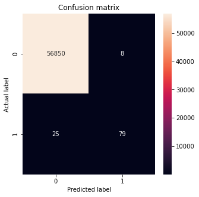

```python
predictions = model.predict(X_test)
predicted_class = []
for prediction in predictions:
    predicted_class.append(np.argmax(prediction))
cm = confusion_matrix(y_test, predicted_class)
plt.figure(figsize=(5,5))
sns.heatmap(cm, annot=True, fmt="d")
plt.title('Confusion matrix')
plt.ylabel('Actual label')
plt.xlabel('Predicted label')
```

It appears our model is very accurate, getting over 99% of cases correct. However, to really tell if this is the model we want, we need to look deeper. Due to the imbalanced data, if the model just guessed not fraud for each transaction it would also get over 99% accuracy.  
Lets take a look at what it predicts for the whole data set.

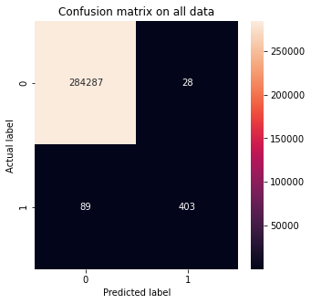

```python
test_predictions = model.predict(df.drop('Class', axis=1))
predicted_class = []
for prediction in test_predictions:
    predicted_class.append(np.argmax(prediction))
cm = confusion_matrix(df['Class'], predicted_class)
plt.figure(figsize=(5,5))
sns.heatmap(cm, annot=True, fmt="d")
plt.title('Confusion matrix on all data')
plt.ylabel('Actual label')
plt.xlabel('Predicted label')
```

We can see that this model misses 89 cases of fraud, and also wrongly classifies 28 legitimate transactions as fraud. For a bank, this means 28 customers will either be contacted to validate their details or have their card blocked as a result of this wrong classification and 89 fraudulent transactions will go undetected  
There is definitely some room to improve, scaling the data to have half fraud and half non fraud might improve our model.

## Balanced Data

First, lets create a dataframe with 492 cases of each class, as we only have 492 cases of fraud in total.

```python
fraud_df = df.loc[df['Class'] == 1]
nfraud_df = df.loc[df['Class'] == 0]
small_df = pd.concat([fraud_df, nfraud_df[:492]])
new_df = small_df.sample(frac=1, random_state=24)
print(new_df['Class'].value_counts()/len(new_df))
```

```
1    0.5
0    0.5
Name: Class, dtype: float64
```

```python
new_train_df, new_test_df = train_test_split(new_df, test_size=0.2)
y_train_new = train_df['Class']
X_train_new = train_df.drop('Class', axis=1)
y_test_new = test_df['Class']
X_test_new = test_df.drop('Class', axis=1)

new_model = keras.Sequential([
    keras.layers.Dense(30, input_shape=(30,), activation='relu'),
    keras.layers.Dense(32, activation='relu'),
    keras.layers.Dense(2, activation='softmax')
])

new_model.compile(optimizer='adam', loss='sparse_categorical_crossentropy', metrics=['accuracy'])

new_model.fit(X_train_new, y_train_new, epochs=20, verbose=2)

test_loss, test_acc = model.evaluate(X_test_new,  y_test_new, verbose=2)
print('\nTest accuracy:', test_acc)
```

```
Train on 227845 samples
227845/227845 - 10s - loss: 0.0058 - accuracy: 0.9991
227845/227845 - 9s - loss: 0.0032 - accuracy: 0.9994
227845/227845 - 9s - loss: 0.0029 - accuracy: 0.9994
227845/227845 - 9s - loss: 0.0027 - accuracy: 0.9994
227845/227845 - 9s - loss: 0.0025 - accuracy: 0.9995
227845/227845 - 9s - loss: 0.0026 - accuracy: 0.9995
227845/227845 - 10s - loss: 0.0024 - accuracy: 0.9995
227845/227845 - 9s - loss: 0.0022 - accuracy: 0.9995
227845/227845 - 10s - loss: 0.0022 - accuracy: 0.9995
227845/227845 - 9s - loss: 0.0021 - accuracy: 0.9994
227845/227845 - 10s - loss: 0.0020 - accuracy: 0.9995
227845/227845 - 10s - loss: 0.0020 - accuracy: 0.9995
227845/227845 - 9s - loss: 0.0020 - accuracy: 0.9995
227845/227845 - 9s - loss: 0.0018 - accuracy: 0.9995
227845/227845 - 10s - loss: 0.0018 - accuracy: 0.9996
227845/227845 - 10s - loss: 0.0018 - accuracy: 0.9996
227845/227845 - 10s - loss: 0.0017 - accuracy: 0.9996
227845/227845 - 9s - loss: 0.0016 - accuracy: 0.9996
227845/227845 - 9s - loss: 0.0017 - accuracy: 0.9996
227845/227845 - 10s - loss: 0.0015 - accuracy: 0.9996
56962/56962 - 1s - loss: 0.0037 - accuracy: 0.9994

Test accuracy: 0.99942064
```

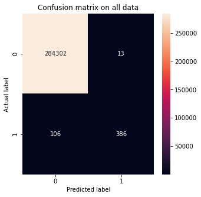

```python
test_predictions = new_model.predict(df.drop('Class', axis=1))
predicted_class = []
for prediction in test_predictions:
    predicted_class.append(np.argmax(prediction))
cm = confusion_matrix(df['Class'], predicted_class)
plt.figure(figsize=(5,5))
sns.heatmap(cm, annot=True, fmt="d")
plt.title('Confusion matrix on all data')
plt.ylabel('Actual label')
plt.xlabel('Predicted label')
```

## Class Weights

First, lets create the weights for each class.

```python
# Pos = class 1, Neg = class 2
pos = df['Class'].value_counts()[1]
neg = df['Class'].value_counts()[0]
total = pos + neg
class_0_weight = (1 / neg)*(total)/2.0
class_1_weight = (1 / pos)*(total)/2.0

class_weights = {0: class_0_weight, 1: class_1_weight}

print("Weight for class 0: {:.2f}".format(class_0_weight))
print("Weight for class 1: {:.2f}".format(class_1_weight))
```

```
Weight for class 0: 0.50
Weight for class 1: 289.44
```

Once we have the weights, we will train the model with the weights in an attempt to improve it. We will also adjust the model slightly. We will be adding a dropout layer will prevent overfitting the model, including validation data and creating a callback to stop the model early if needed.

```python
train_df, val_df = train_test_split(train_df, test_size=0.2)
train_features = train_df.drop('Class', axis=1)
train_labels = train_df['Class']
val_features = val_df.drop('Class', axis=1)
val_labels = val_df['Class']

early_stopping = tf.keras.callbacks.EarlyStopping(
    monitor='val_auc',
    verbose=1,
    patience=10,
    mode='max',
    restore_best_weights=True)

metrics = [
      keras.metrics.TruePositives(name='tp'),
      keras.metrics.FalsePositives(name='fp'),
      keras.metrics.TrueNegatives(name='tn'),
      keras.metrics.FalseNegatives(name='fn'),
      keras.metrics.BinaryAccuracy(name='accuracy'),
      keras.metrics.Precision(name='precision'),
      keras.metrics.Recall(name='recall'),
      keras.metrics.AUC(name='auc'),
]


weighted_model = keras.Sequential([
    keras.layers.Dense(16, input_shape=(X_train.shape[-1],), activation='relu'),
    keras.layers.Dropout(0.5),
    keras.layers.Dense(1, activation='sigmoid')
])

weighted_model.compile(
    optimizer=keras.optimizers.Adam(lr=1e-3),
    loss=keras.losses.BinaryCrossentropy(),
    metrics=metrics
)

weighted_history = weighted_model.fit(
    train_features,
    train_labels,
    epochs=100,
    callbacks=[early_stopping],
    validation_data=(val_features, val_labels),
    class_weight=class_weights
)
```

[output not shown]

```
Train on 145820 samples, validate on 36456 samples
Epoch 00030: early stopping
```

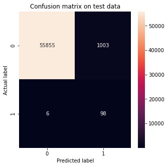

```python
test_predictions_weighted = weighted_model.predict(X_test)
cm = confusion_matrix(y_test, test_predictions_weighted > 0.5)
plt.figure(figsize=(5,5))
sns.heatmap(cm, annot=True, fmt="d")
plt.title('Confusion matrix on test data')
plt.ylabel('Actual label')
plt.xlabel('Predicted label')
```

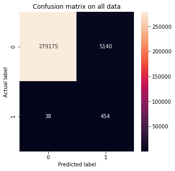

```python
all_predictions_weighted = weighted_model.predict(df.drop('Class', axis=1))
cm = confusion_matrix(df['Class'], all_predictions_weighted > 0.5)
plt.figure(figsize=(5,5))
sns.heatmap(cm, annot=True, fmt="d")
plt.title('Confusion matrix on all data')
plt.ylabel('Actual label')
plt.xlabel('Predicted label')
```

We have reduced the amount of False Negatives with 38, but the amount of False Postives has increased. In an attempt to improve this further, we run our model on the evenly distributed data.

```python
sample_train_df, sample_val_df = train_test_split(new_train_df, test_size=0.2)
sample_train_features = sample_train_df.drop('Class', axis=1)
sample_train_labels = sample_train_df['Class']
sample_val_features = sample_val_df.drop('Class', axis=1)
sample_val_labels = sample_val_df['Class']

sample_weighted_history = weighted_model.fit(
    sample_train_features,
    sample_train_labels,
    epochs=100,
    callbacks=[early_stopping],
    validation_data=(sample_val_features, sample_val_labels),
    class_weight=class_weights
)
```

[output not shown]

```
Train on 629 samples, validate on 158 samples
Epoch 00012: early stopping
```

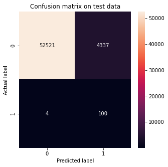

```python
test_predictions_weighted = weighted_model.predict(X_test_new)
cm = confusion_matrix(y_test_new, test_predictions_weighted > 0.5)
plt.figure(figsize=(5,5))
sns.heatmap(cm, annot=True, fmt="d")
plt.title('Confusion matrix on test data')
plt.ylabel('Actual label')
plt.xlabel('Predicted label')
```

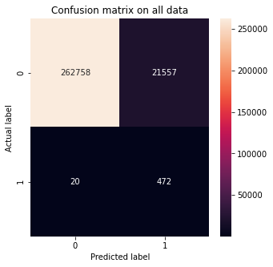

```python
all_predictions_weighted = weighted_model.predict(df.drop('Class', axis=1))
cm = confusion_matrix(df['Class'], all_predictions_weighted > 0.5)
plt.figure(figsize=(5,5))
sns.heatmap(cm, annot=True, fmt="d")
plt.title('Confusion matrix on all data')
plt.ylabel('Actual label')
plt.xlabel('Predicted label')
```

We have again decreased the number of False Negatives to 20, but as a result increased the number of False Positives to 21,557. 4.07% of frauds go undetected, while 7.59% of legitimate transactions are wrongly identified as fraud.

## Conclusion

There is clearly a decision to be made by banks. Either detect more fraud and risk annoying customers with a high number of legitimate transactions classed as fraudulent, or detect slightly less fraudulent transactions but keep False Positives low.  
Some considerations for improvement:

- Remove the time column as it is unclear how it helps the model predict fraud
- Setting an initial bias to help with initial learning
- Alter model layers and parameters